# Gradient Forest analysis - Part 1

Candidate SNPs identification

Author

Juliette Archambeau

Published

April 28, 2023

# Introduction

Most analyses conducted in the present report were conducted following Fitzpatrick et al. (2021) and Capblancq et al. (2023), and the R code arebased on [the github repository](https://github.com/fitzLab-AL/geneticOffsetR) associated with Fitzpatrick et al. (2021).

**Goal:** Identify candidate SNPs for local adaptation to climate using the **Gradient Forest (GF) algorithm**.

To this goal, we will apply the GF algorithm to:

- the ‘raw’ or *uncorrected* allele frequencies (**GF-raw** in Fitzpatrick et al. (2021) and Capblancq et al. (2023)).
- the *corrected* allele frequencies, i.e. the allele frequencies corrected for population structure = corrected for population reladness. In Fitzpatrick et al. (2021) and Capblancq et al. (2023), they use the population genetic variance-covariance matrix from Bayenv 2 to correct for population structure and called the matrix of corrected allele frequencies **GF-X**. From Fitzpatrick et al. (2021): ‘The GF-X approach was included to explore a more robust approach to allele frequency estimation that corrects for finite sampling and population relatedness prior to feeding into GF for outlier detection.’ In our case, we extract the matrix of corrected allele frequencies using the latent factor mixed model (LFMM) approach; see section 5 ‘Corrected allele frequencies’ in the `6_LEAanalysis.qmd` report.

**Strengths** of the GF algorithm: nonparametric (nonlinear allele frequency gradients), makes no assumption about the particular form of the gene–environment relationship, incorporates multivariate predictors, interactions among predictors.

**Weakness**: not controlling for demographic history.

From Gain et al. (2023): ‘Nonlinearity makes the GF model more flexible than linear models, but the additional degrees of freedom may not always be desirable when resolving bias-variance trade-offs.’

GF models are fitted to each locus individually and a $R^2$ is obtained for each locus. Empirical p-values are then calculated.

The **empirical p-value approach** is described in Lotterhos and Whitlock (2014): ‘[…] if the set of neutral loci is large enough, the statistical significance of a putatively selected outlier locus could be assessed by its quantile in the empirical distribution of differentiation measures obtained from the neutral set.’

In Fitzpatrick et al. (2021), the authors use a set of intergenic SNPs to obtain a distribution of $R^2$ values, which is considered as the empirical null distribution of $R^2$ values. They calculate the empirical p-values by determining the rank of the $R^2$ value for each locus within the distribution of $R^2$ values from the intergenic SNPs.

In the present report, we randomly sample $n$ SNPs and we compare $R^2$ value of each locus to the $R^2$ distribution of the $n$ randomly selected SNPs. Thus, the **empirical p-value** $\hat{p}$ of the locus $l$ is equal to:

$$\hat{p}_l = 1 - (r_l / n)$$
with $r_l$ being the rank of the $R^2$ value of locus $l$ within the distribution of $R^2$ values of the $n$ randomly selected SNPs.

# Options, parameters and functions

## Functions from Fitzpatrick et al. (2021)

The following functions are based on the functions written by MC Fitzpatrick (Appalachian Lab, Frostburg, MD) and available in the Github repository: https://github.com/fitzLab-AL/geneticOffsetR

### `format_geno`

Function to format the genomic data used in the GF analysis.

Inputs:

```r
format_geno <- function(genodata, selected_snps, rm_rare_alleles, selected_random_snps){

  # run GF on all SNPs or a subset of selected SNPs?
  if(length(selected_snps)>1){genodata <- genodata %>% dplyr::select(all_of(selected_snps))}

  # remove SNPs that are polymorphic in fewer than five populations?
  if(rm_rare_alleles==T){genodata  <- genodata %>% dplyr::select(which(unlist(lapply(lapply(., unique), length))>=6))}

  # run GF on a random subset of SNPs?
  if(selected_random_snps>0){genodata <- genodata %>% dplyr::select(sample(colnames(.),selected_random_snps))}

  return(genodata)
  }
```

### `run_gf_ind`

Function to run the GF models individually for each locus.

Inputs:

- `genodata`: the genomic dataset with SNPs in columns and populations in rows (with population names as row names)
- `climdata`: table with the climatic variables with a row for each population
- `clim_var`: vector with the names of the climatic variables to be used in the GF models
- `ntree`: number of trees to fit
- `cores`: number of processors to use

```r
run_gf_ind <- function(genodata, climdata, clim_var, ntree, cores){

  # create custom object to hold output
  gf_output_obj <- setClass("gf_output_obj", slots = c(gf_data="data.frame", gf_impts="list"))

  # check that populations are in the same order in the genomic and climatic datasets
  if(identical(climdata$pop,rownames(genodata))==F){
    stop("Populations are not in the same order in the genomic and climatic tables.")
  }

  # check to make sure user has set the number of cores (min = 1)
  if(is.na(cores)){
    stop(paste0("You need to provide the number of processors to use (i.e., cores = 4). You have a maximum of ", detectCores(), " cores available."))
  }

  if(cores>detectCores()){
    stop(paste0("You have a maximum of ", detectCores(), " cores available."))
  }


    # fit the GF model to each SNP individually and in parallel
    cl <- makeCluster(cores, setup_strategy = "sequential")
    registerDoParallel(cl)

    gf_impts <- foreach(k=1:ncol(genodata), .verbose=F, .packages=c("gradientForest")) %dopar%{
      locus <- data.frame(genodata[,k])
      names(locus) <- colnames(genodata)[k]
      gf_mod <- gradientForest(data.frame(climdata[, clim_var], locus),
                               predictor.vars=clim_var, response.vars=colnames(genodata)[k],
                               corr.threshold=0.5, ntree=ntree, trace=F)

      if(!is.null(gf_mod)){data.frame(variable=names(importance(gf_mod)),
                                      impts = importance(gf_mod),
                                      snp = colnames(genodata)[k])}
    }

    stopCluster(cl)


    return(gf_output_obj(gf_data = data.frame(genodata), gf_impts = gf_impts))

  }
```

### `extract_pvals`

Function to calculate the empirical p-values

Inputs:

- `gf_outputs`: output object from `run_gf_ind` function
- `neutral_snps`: subset of randomly selected SNPs used as ‘neutral’ SNPs to develop the empirical null model

```r
extract_pvals <- function(gf_outputs, neutral_snps){

# extract the R2 importance values from the GF outputs and arrange them in a
  # dataframe with a row for each SNP with R2>0 and a column with the R2 of each climatic variable
gf_R2 <-  gf_outputs@gf_impts %>%
    bind_rows() %>%
    pivot_wider(names_from = "variable", values_from = "impts") %>%
    rowwise() %>%
    mutate(totalR2 = sum(c_across(where(is.numeric)))) %>%
    arrange(snp)

# extend the table to all the SNPs used in the GF analysis
  dat <- gf_outputs@gf_data %>%
    t() %>%
    as.data.frame() %>%
    rownames_to_column("snp") %>%
    dplyr::select(snp) %>%
    as_tibble() %>%
    left_join(gf_R2, by="snp") %>%
    mutate(across(where(is.numeric), ~replace_na(.x, 0)))


# subset of random SNPs considered as the 'neutral' SNPs
  neutral_snps_R2 <- dat %>%
    filter(snp %in% neutral_snps)

pV <- sapply(1:nrow(dat), function(x, dat, neutral_snps, neutral_snps_R2){
    snps2Rank <- rbind(dat[x,], neutral_snps_R2) %>%
      distinct() %>%
      dplyr::select(-snp)
    P <- apply(snps2Rank, 2, function(y){
      rankSNP <- frank(y)
      return(1-rankSNP[1]/length(rankSNP))
    })}, dat, neutral_snps, neutral_snps_R2)

  # format output as data.frame
  pV <- t(pV)
  colnames(pV) <- paste("pval_", colnames(pV), sep="")
  pV <- data.frame(dat, pV)
  return(pV)
}
```

### `identify_GFoutliers`

Function to identify the GF outliers

Inputs:

- `list_clim_var`: list of vectors with the names of the climatic variables to be used in the GF models
- `nb_neutral_snps`: number of random SNPs to sample from the genomic data to develop the empirical null model

```r
identify_GFoutliers <- function(genodata,
                                climdata,
                                clim_var,
                                ntree,
                                rm_rare_alleles,
                                selected_snps,
                                cores,
                                selected_random_snps,
                                nb_neutral_snps){

genodata <- format_geno(genodata,
                        selected_snps,
                        rm_rare_alleles,
                        selected_random_snps)

# we sample random SNPs that are considered as neutral SNPs
neutral_snps <- sample(colnames(genodata),nb_neutral_snps,replace = F)


gf_outputs <-  run_gf_ind(genodata = genodata, climdata = climdata, clim_var = clim_var, ntree = ntree, cores)

gf_pvals <- extract_pvals(gf_outputs=gf_outputs,neutral_snps=neutral_snps)


outliers005 <- gf_pvals %>% filter(pval_totalR2<0.05) %>% pull(snp)
outliers001 <- gf_pvals %>% filter(pval_totalR2<0.01) %>% pull(snp)
outliers_bonf <- gf_pvals %>% filter(pval_totalR2<0.01/length(gf_pvals$snp)) %>% pull(snp) # bonferroni correction

gf_out <- list(genodata = genodata,
               clim_var= clim_var,
               gf_pvals = gf_pvals,
               outliers = list(outliers005 = outliers005,
                               outliers001 = outliers001,
                               outliers_bonf = outliers_bonf))

return(gf_out)
}
```

# Downloading the data

## Genomic data

We load the *uncorrected* and *corrected* allele frequency matrices in a list.

The *uncorrected* allele frequency matrix is already a matrix a population-level allele frequencies, i.e. so with the number of populations in rows and the number of genetic markers in columns.

The *corrected* allele frequency matrix is a matrix of genotype-level (ie individual-level) allele frequencies, i.e. so with the number of genotypes (ie clones, individuals) in rows and the number of genetic markers in columns. We have to transform it in a population-level allele frequency matrix.

```r
# we load the two genomic matrices
list_geno <- list(mat_raw = read.csv(here::here("data/DryadRepo/ImputedGenomicData_AlleleFrequencies_withoutmaf.csv"),
                                     row.names = 1),
                  mat_X = read.csv(here::here("data/DryadRepo/CorrectedAlleleFrequencies_withoutmaf.csv"),
                                     row.names = 1))


# we calculate the population-level allele frequencies for the corrected matrix
list_geno$mat_X <- list_geno$mat_X %>%
  rownames_to_column(var="pop") %>%
  mutate(pop=str_sub(pop,1,3)) %>%
  group_by(pop) %>%
  summarise_all(~sum(., na.rm = TRUE)/((n()-sum(is.na(.)))*2)) %>%
  column_to_rownames("pop")
```

**Comment:** This data contains the population-based allele frequencies of the **minor allele**. The minor allele was identified as the minor allele across all individuals. However, as the populations do not contain the same number of individuals, the average of the population-based allele frequencies is higher than 0.5 for some SNPs.

```r
high_freqs <- lapply(list_geno, function(x)

  x %>%
  summarise_all(mean) %>%
  pivot_longer(everything(),names_to = "snp",values_to= "mean") %>%
  filter(mean>0.5))
```

For the corrected matrix, 0 have average population-based allele frequencies higher than 0.5. However, for the uncorrected matrix, 168 SNPs have average population-based allele frequencies higher than 0.5. Can we still call them population minor allele frequencies?

## Climatic data

We load the population-specific climatic information for the climatic variables of interest. We use the following climatic variables (set 3 in the report `2_RedundancyAnalysis_part1.Rmd`):

```r
# Selected climatic variables
# ===========================
clim_var <- readRDS(here("data/ClimaticData/NamesSelectedVariables.rds"))

extract_climatedt_metadata(var_clim = clim_var) %>%
  dplyr::select(label,description,unit) %>%
  set_colnames(str_to_title(colnames(.))) %>%
  kable_mydf()
```

| Label | Description | Unit |
| --- | --- | --- |
| bio1 | Mean annual temperature | Celsius degrees (°C) |
| bio3 | Isothermality (bio2/bio7) (×100) | index |
| bio4 | Temperature seasonality (standard deviation ×100) | Celsius degrees (°C) |
| bio12 | Annual precipitation | Millimeters (mm) |
| bio15 | Precipitation seasonality (coefficient of variation) | index |
| SHM | Summer heat moisture index | °C / mm |

```r
# Past and future climatic data
# =============================
source(here("scripts/functions/generate_clim_datasets.R"))
clim_dfs <- generate_clim_datasets(clim_var)
```

# Identify GF outliers

```r
set.seed(55)

gf_out <- lapply(list_geno, function(geno)

identify_GFoutliers(genodata = geno,
                    climdata = clim_dfs$clim_past,
                    clim_var = clim_var,
                    rm_rare_alleles = T,
                    selected_snps = "all",
                    ntree=500,
                    cores = 9,
                    selected_random_snps = 0,
                    nb_neutral_snps = 1000)) %>%
  setNames(c("gf_raw","gf_X"))

saveRDS(gf_out, here::here("outputs/GF/gf_outliers.rds"))
```

# Common outliers with RDA

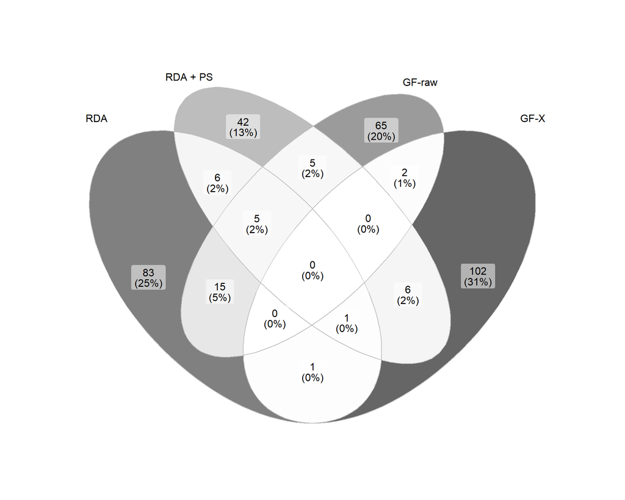

```r
rda_outliers <- readRDS(here::here("outputs/RDA/RDA_outliers.rds"))
gf_out <- readRDS(here::here("outputs/GF/gf_outliers.rds"))


list_outliers <- list("RDA" = rda_outliers[[3]]$outliers$snp,
                      "RDA + PS" = rda_outliers[[4]]$outliers$snp,
                      "GF-raw" = gf_out$gf_raw$outliers$outliers001,
                      "GF-X" = gf_out$gf_X$outliers$outliers001)

ggVennDiagram(list_outliers,lty="solid", size=0.2) +
  scale_fill_gradient2(low = "white", high = 'gray40') + scale_color_manual(values = c("grey", "grey", "grey", "grey")) +
  guides(fill = "none") +
  #labs(caption='Set 3 climatic variables') +
  theme(text = element_text(size=16),
        plot.caption = element_text(hjust=0.5, size=rel(1.2))) +
  scale_x_continuous(expand = expansion(mult = .2))
```

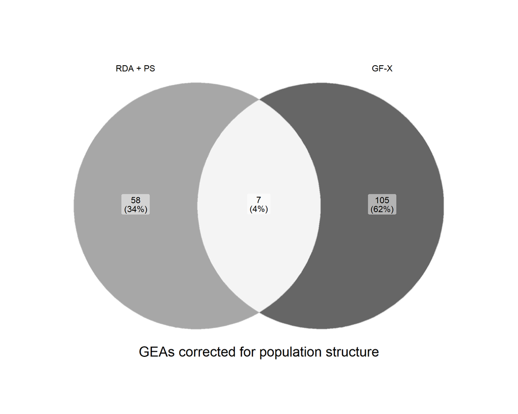

```r
ggVennDiagram(list_outliers[c(2,4)],lty="solid", size=0.2) +
  scale_fill_gradient2(low = "white", high = 'gray40') + scale_color_manual(values = c("grey", "grey", "grey", "grey")) +
  guides(fill = "none") +
  labs(caption='GEAs corrected for population structure') +
  theme(text = element_text(size=16),
        plot.caption = element_text(hjust=0.5, size=rel(1.2))) +
  scale_x_continuous(expand = expansion(mult = .2))
```

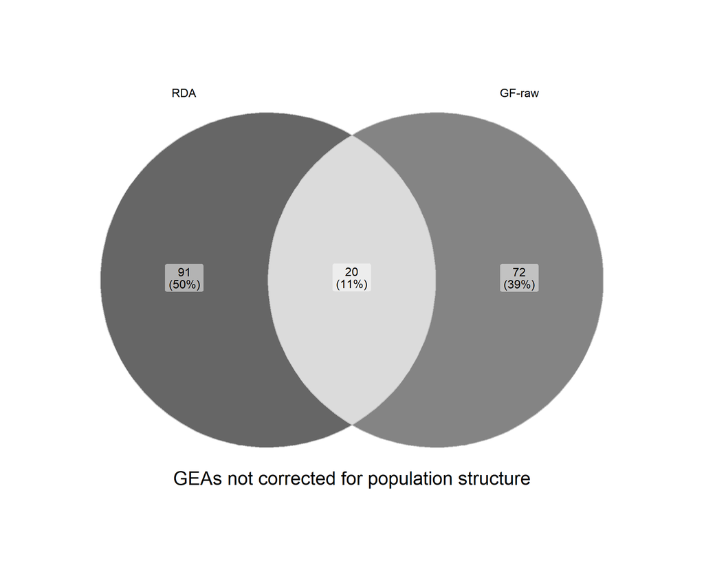

```r
ggVennDiagram(list_outliers[c(1,3)],lty="solid", size=0.2) +
  scale_fill_gradient2(low = "white", high = 'gray40') + scale_color_manual(values = c("grey", "grey", "grey", "grey")) +
  guides(fill = "none") +
  labs(caption='GEAs not corrected for population structure') +
  theme(text = element_text(size=16),
        plot.caption = element_text(hjust=0.5, size=rel(1.2))) +
  scale_x_continuous(expand = expansion(mult = .2))
```

## References

Capblancq, Thibaut, Susanne Lachmuth, Matthew C Fitzpatrick, and Stephen R Keller. 2023. “From Common Gardens to Candidate Genes: Exploring Local Adaptation to Climate in Red Spruce.” *New Phytologist* 237 (5): 1590–1605.

Fitzpatrick, Matthew C, Vikram E Chhatre, Raju Y Soolanayakanahally, and Stephen R Keller. 2021. “Experimental Support for Genomic Prediction of Climate Maladaptation Using the Machine Learning Approach Gradient Forests.” *Molecular Ecology Resources*.

Gain, Clément, Benedicte Rhone, Philippe Cubry, Israfel Salazar, Florence Forbes, Yves Vigouroux, Flora Jay, and Olivier François. 2023. “A Quantitative Theory for Genomic Offset Statistics.” *bioRxiv*, 2023–01.

Lotterhos, Katie E, and Michael C Whitlock. 2014. “Evaluation of Demographic History and Neutral Parameterization on the Performance of FST Outlier Tests.” *Molecular Ecology* 23 (9): 2178–92.